# Homework 5

Erika Luna

October 16, 2019

# Exercise 1: Explain the value of the here::here package

The ‘here’ function from the ‘here’ package is very useful to do a couple of things faster, such as navigating in our project’s directory. Since ‘here’ knows the root directory in R, navigating through out subdirectories becomes a lot easier as we do not have to specify the whole directory.

‘here’ is also a useful function when sharing code, because it doesn’t matter the operating system (Windows, Linux, etc.) that our collabotators use, this function runs independently.

# Exercise 2: Factor management

Task: Choose one dataset (of your choice) and a variable to explore. After ensuring the variable(s) you are exploring are indeed factors you should 2.1 drop factors / levels and 2.2. reorder levels based on knowledge from data.

When applying the str function to continent we can know what type of variable “continent” is.

```r
str(gapminder$continent)
```

```
##  Factor w/ 5 levels "Africa","Americas",..: 3 3 3 3 3 3 3 3 3 3 ...
```

The result above shows us that continent is a factor with 5 levels (5 continents).

## 2.1: Drop factor / levels

To show more explicitly how many levels are in continent we can use the function nlevels().

```r
gapminder$continent %>%
  nlevels()
```

```
## [1] 5
```

To know how many observations are in our dataset we use the nrow() function.

```r
nrow(gapminder)
```

```
## [1] 1704
```

If we want to drop a level from our dataset, we use the droplevels() function. In the following code, we drop Oceania from our dataset by filtering our data with all continents, but Oceania.

```r
gapminder_dropped <- gapminder %>%
  filter(continent == c("Asia", "Europe", "Americas", "Africa")) %>%
  droplevels()
```

Now we look into our modified dataset to see how many levels we ended up with.

```r
gapminder_dropped$continent %>%
  nlevels()
```

```
## [1] 4
```

And also how many observations.

```r
gapminder_dropped %>%
  nrow()
```

```
## [1] 420
```

## 2.2 Reorder levels based on knowledge from data

Now we reorder the levels based on the maximum life expectancy for each of our levels (continents).

```r
gap_maxlife <- gapminder_dropped %>%
  group_by(continent, country) %>%
  summarize(max_lifeExp = max(lifeExp))
```

We then look at how many levels we have in this new dataset.

```r
gap_maxlife$country %>%
  nlevels()
```

```
## [1] 140
```

140 levels is to much to display in a plot, so we will drop some levels and keep only countries in Europe.

```r
gap_europe <- gap_maxlife %>%
  filter(continent == "Europe") %>%
  droplevels()
```

We now make our plot.

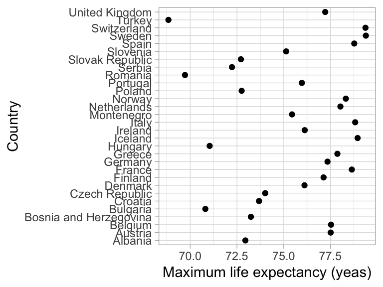

```r
gap_europe %>%
  ggplot() +
  geom_point(aes(country, max_lifeExp)) +
  ylab("Maximum life expectancy (yeas)") +
  xlab("Country") +
  coord_flip() +
  theme_light()
```

The plot above could be more informative by putting our levels in ascendent order based on each level’s life expectancy.

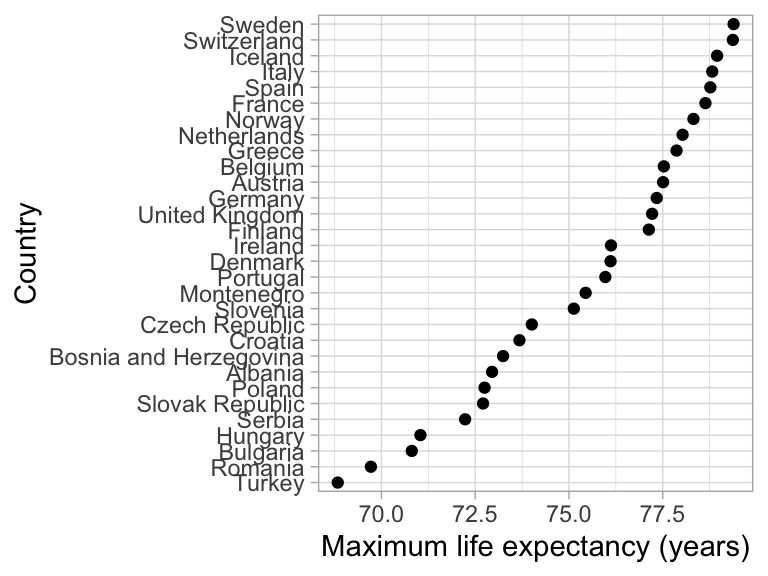

```r
gap_europe %>%
  ggplot() +
  geom_point(aes(fct_reorder(country, max_lifeExp, min), max_lifeExp)) +
  ylab("Maximum life expectancy (years)") +
  xlab("Country") +
  coord_flip() +
  theme_light()
```

# Exercise 3: File input/output (I/O)

Let’s say we are interested in sharing the data for North America with our collegues. We first have to filter our gapminder data.

```r
gapminder_ame <- gapminder %>%
  filter(continent == "Americas") %>%
  filter(country == "Canada" |
         country == "Mexico" |
         country == "United States")
```

Now we write a csv of the filtered data.

```r
write_csv(gapminder_ame,
          here::here("hw05", "gapminder_ame.csv"))
```

Now, when our collegues open the file, they would use the function ‘read_csv’.

```r
gapminder_ame_csv <- read_csv(here("hw05", "gapminder_ame.csv"))
gapminder_ame_csv %>%
  DT::datatable()
```

|  | country | continent | year | lifeExp | pop | gdpPercap |
| --- | --- | --- | --- | --- | --- | --- |
| 1 | Canada | Americas | 1952 | 68.75 | 14785584 | 11367.16112 |
| 2 | Canada | Americas | 1957 | 69.96 | 17010154 | 12489.95006 |
| 3 | Canada | Americas | 1962 | 71.3 | 18985849 | 13462.48555 |
| 4 | Canada | Americas | 1967 | 72.13 | 20819767 | 16076.58803 |
| 5 | Canada | Americas | 1972 | 72.88 | 22284500 | 18970.57086 |
| 6 | Canada | Americas | 1977 | 74.21 | 23796400 | 22090.88306 |
| 7 | Canada | Americas | 1982 | 75.76 | 25201900 | 22898.79214 |
| 8 | Canada | Americas | 1987 | 76.86 | 26549700 | 26626.51503 |
| 9 | Canada | Americas | 1992 | 77.95 | 28523502 | 26342.88426 |
| 10 | Canada | Americas | 1997 | 78.61 | 30305843 | 28954.92589 |

[output cut: 26 more lines]

However, notice that the variable continent has now become a character.

```r
class(gapminder_ame_csv$continent)
```

```
## [1] "character"
```

So we should warn our collegues that this must be transformed into a factor.

# Exercise 4: Visualization design

On Assignment 1 I made the graph shown below. At the time it seemed nice to me, but now that I’ve learned how to make pretty and most importantly, informative graphs with ggplot I will change some aspects if it.

```r
old_plot <- ggplot(gapminder, aes(continent, pop)) +
  geom_col()
```

```r
new_plot <- gapminder %>%
  ggplot() +
  geom_col(aes(reorder(continent, -pop), pop)) +
  ylab("Population") +
  xlab("Continent") +
  scale_y_continuous(labels = scales::comma) +
  theme_light()
```

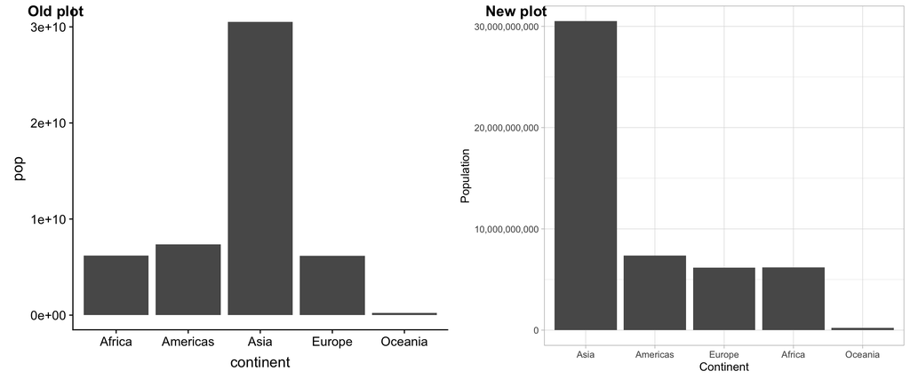

```r
plots <- plot_grid(old_plot, new_plot, ncol = 2,
          labels = c("Old plot", "New plot"))
plots
```

# Exercise 5: Writing figures to file

Task: Use ggsave() to explicitly save a plot to file. Include the exported plot as part of your repository and assignment.

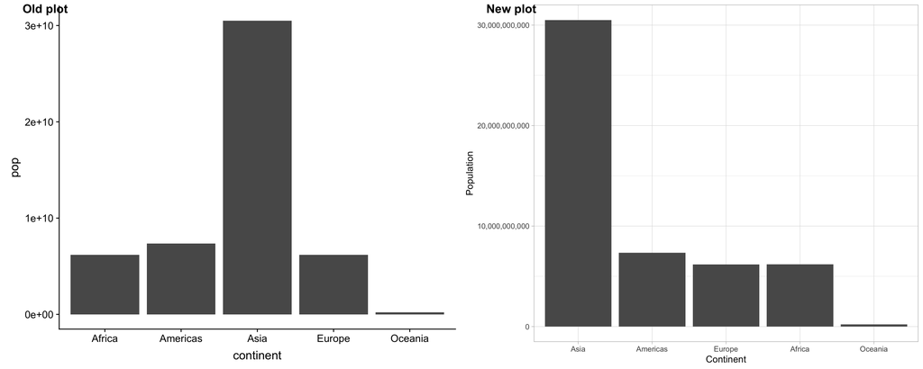

*A better version of a plot from assignment 1*

```r
plots_file <- "plots.png" #file name

plot_path <- here::here("hw05", "plots") #path

ggsave(plots_file,
       plots,
       device = "png",
       path = plot_path,
       width = 10, height = 4,
       scale = 1.5)
```